# Single-level categorical model

The categorical (cat) model adds item classes to the spatial model:

- distance to the last item (`rho_delta`),
- direction relative to the last move (`rho_psi`),
- absolute direction (`fourier_coef`),
- a class-transition matrix (`b_v`) sets how likely the next item is to be the same class as the last (“sticking”) or a different one.

We simulate one person with known parameters, fit the model, and check it recovers them.

Code: `cat.R`.

```r
# import packages and load our functions
source("../../../../functions/set_up_FoMo.R")
```

```
[1] "set_up_FoMo.R: random seed set to 65 (FOMO_SEED)"
```

```r
# sampler settings (the same in every example; set FOMO_EXAMPLE_ITER for a quick run)
n_iter <- as.integer(Sys.getenv("FOMO_EXAMPLE_ITER", "300"))  # warmup and sampling iterations per chain
n_post_draws <- 50   # posterior draws for posterior predictive simulation
```

## 1 From stick/switch to a transition matrix

The original model (Clarke, Hunt & Hughes, 2022; Clarke & Hughes, 2026) had two item-class parameters, for two classes A and B: a class weight $b_a$ (above 0 favours class A) and a stick/switch rate $b_s$ (above 0 favours the class just selected). An item’s weight is the product of $\text{logit}^{-1}(b_a)$ (or $1 - \text{logit}^{-1}(b_a)$ for class B) and $\text{logit}^{-1}(b_s)$ (or $1 - \text{logit}^{-1}(b_s)$ for a switch).

Here the classes enter through one transition matrix, `b_v`: row $c$ holds the probabilities of each class being selected next, after an item of class $c$ (per item, so the counts of each class still matter). With two classes the two parameterisations are the same model. Each row’s log-odds of class A over class B are:

$$\log\frac{b_v[A, A]}{b_v[A, B]} = b_a + b_s, \qquad
\log\frac{b_v[B, A]}{b_v[B, B]} = b_a - b_s,$$

so $b_a$ is the average of the two rows’ log-odds and $b_s$ half their difference. However, two things differ:

- With three or more classes the matrix is more general: $n(n-1)$ free probabilities against the papers’ $n$ (class weights and one stick/switch rate).
- A trial’s first selection, which has no previous item, is weighted by the matrix’s stationary distribution (each class’s long-run share) rather than by $b_a$.

## 2 Simulate

Two conditions, 25 trials each, on an 8 $\times$ 8 grid with a quarter of cells empty and two item classes:

- Condition *one* is sticky (repeat probabilities 0.85 and 0.75) and prefers the four cardinal directions;
- Condition *two* is closer to random (0.6) and prefers moving right.

Each trial’s first selection has no previous item, so it is weighted by class only, using the stationary distribution of the transition matrix (each class’s long-run share): in condition *one* that favours class 1.

```r
spec <- list(
  K = 2,
  nrow = 8, ncol = 8,
  prop_missing = 0.25,
  v_type = "cat",
  n_classes = 2)

stim <- generate_stim(spec, n_trials = 25)
```

```r
simparams_cat <- list(
  b_v_pr = list(matrix(c(0.85, 0.15,
                         0.25, 0.75),
                       nrow = 2),
                matrix(c(0.60, 0.40,
                         0.40, 0.60),
                       nrow = 2)))


simparams_spa <- list(
  rho_delta_mu = c(1, 1),
  rho_psi_mu = c(0, 0),
  # absolute direction, Fourier-124 ({cos, sin} per harmonic): condition
  # one prefers the four cardinal directions (h4), two rightwards (h1)
  #                       h1: a, b   h2: a, b   h4: a, b
  fourier_coef_mu = rbind(c(0,   0,     0, 0,     0.8, 0),
                          c(1.5, 0,     0, 0,     0,   0)))

simparams <- append(simparams_spa, simparams_cat)

sl_sim <- prep_stan_list(stim, simparams)

sim <- sim_fomo(sl_sim, iter = 1, chains = 1)

found <- extract_pred(sim, stim)
```

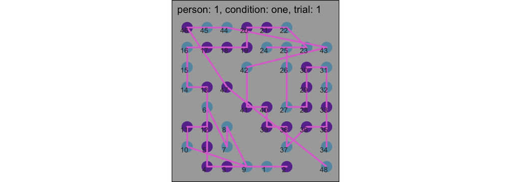

Figure 1: One simulated trial: items (coloured by class) and selection order.

```r
plot_trial(found, stim, trial = 1)
```

We should expect to see a difference in the run statistics between the two conditions:

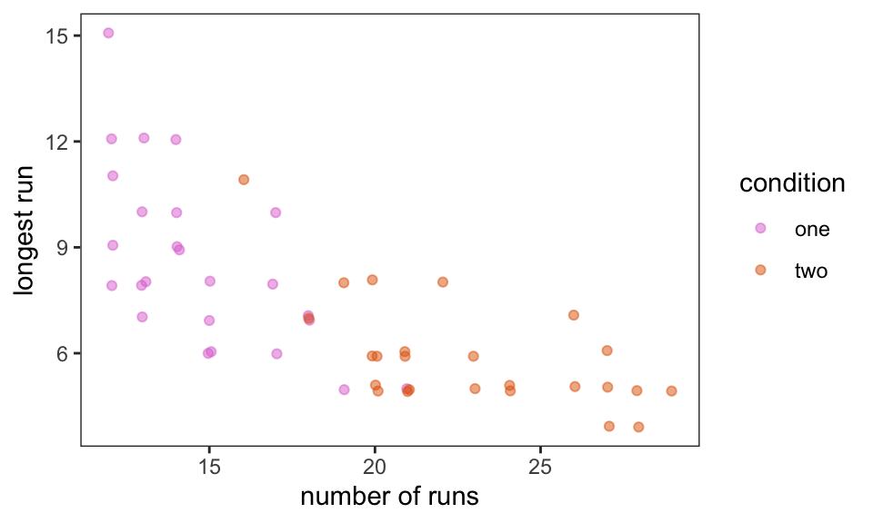

Figure 2: Runs of same-class selections per trial. Stickier behaviour gives fewer, longer runs.

```r
plot_runs(compute_runs(found))
```

Compute trial stats for comparing against the fitted model’s posterior predictions:

```r
trial_stats <- compute_trial_stats(found)

head(trial_stats)
```

```
# A tibble: 6 × 9
  trial condition person n_found best_r mean_itd   pao n_runs max_run_length
  <int> <fct>      <int>   <int>  <dbl>    <dbl> <dbl>  <int>          <int>
1     1 one            1      48  0.438    0.230  42.9     17              6
2     2 one            1      48  0.537    0.270  68.7     13             10
3     3 one            1      48  0.376    0.236  44.5     14              9
4     4 one            1      48  0.286    0.270  62.8     14             10
5     5 one            1      48  0.547    0.274  65.1     17              8
6     6 one            1      48  0.271    0.277  67.4     18              7
```

## 3 Fit

We now fit the single-level categorical version of FoMo to our simulated data. Four chains of 500 warmup and 500 sampling iterations.

*Note*: `save_selections = FALSE` by default, because storing a prediction for every selection and draw is too big to read back into R on large datasets. For per-selection accuracy we set it to `TRUE` here; on large datasets, use `predict_fomo()` on a subset of draws instead.

```r
sl <- prep_stan_list(stim, found = found, save_selections = TRUE)
```

```r
# a fixed seed, so the chains are the same on every run
fit <- fit_fomo(sl, iter = n_iter, chains = 4, seed = FOMO_SEED)
```

## 4 Diagnostics

Posterior medians and 97% HPDIs, the values the data were simulated from (`true`, and whether each is `inside` its HPDI), and convergence (R-hat, ESS). About one in 33 simulation values should fall outside its HPDI by chance. R-hat above 1.01, or a bulk or tail ESS in the low hundreds, means the chains haven’t mixed well enough to trust the tails of the posterior. The summary’s last line names the worst parameter (random effects included); the table colours R-hat and ESS green (good), orange (acceptable) or red (bad). With this few iterations some low ESS values are expected; a real analysis should use more (see `examples/real_data/fit_models/`).

```r
# estimates and convergence, and parameter recovery: are the values used
# to simulate the data inside the posterior's 97% HPDIs?
fomo_summary(fit, sim, cond_labels = levels(stim$condition))
```

**Fixed effects (median and 97% HPDI)**

| parameter | condition | component | lower | median | upper | true | inside | rhat | ess_bulk | ess_tail |
| --- | --- | --- | --- | --- | --- | --- | --- | --- | --- | --- |
| rho_delta | one |  | 0.96 | 1.03 | 1.10 | 1.01 | TRUE | 1.00 | 4083 | 1618 |
| rho_delta | two |  | 0.90 | 0.96 | 1.02 | 0.99 | TRUE | 1.00 | 4930 | 1655 |
| rho_psi | one |  | -0.44 | -0.15 | 0.13 | 0.01 | TRUE | 1.00 | 4455 | 1732 |
| rho_psi | two |  | -0.19 | 0.12 | 0.44 | 0.00 | TRUE | 1.01 | 5397 | 1385 |
| fourier_coef | one | h1 cos | -0.20 | -0.08 | 0.05 | -0.01 | TRUE | 1.00 | 5793 | 1330 |
| fourier_coef | two | h1 cos | 1.20 | 1.35 | 1.48 | 1.49 | FALSE | 1.00 | 5366 | 1381 |
| fourier_coef | one | h1 sin | -0.10 | 0.01 | 0.15 | -0.02 | TRUE | 1.00 | 6009 | 1456 |
| fourier_coef | two | h1 sin | -0.04 | 0.08 | 0.20 | 0.00 | TRUE | 1.00 | 4472 | 1537 |
| fourier_coef | one | h2 cos | -0.08 | 0.02 | 0.11 | 0.01 | TRUE | 1.00 | 5847 | 1561 |
| fourier_coef | two | h2 cos | -0.10 | 0.02 | 0.11 | 0.00 | TRUE | 1.00 | 5300 | 1394 |
| fourier_coef | one | h2 sin | -0.03 | 0.14 | 0.30 | -0.01 | TRUE | 1.00 | 3787 | 1681 |
| fourier_coef | two | h2 sin | -0.11 | 0.00 | 0.13 | 0.01 | TRUE | 1.00 | 6288 | 1506 |
| fourier_coef | one | h4 cos | 0.69 | 0.80 | 0.92 | 0.81 | TRUE | 1.00 | 4392 | 1811 |
| fourier_coef | two | h4 cos | -0.13 | -0.03 | 0.05 | -0.01 | TRUE | 1.00 | 3945 | 1406 |
| fourier_coef | one | h4 sin | -0.28 | -0.09 | 0.10 | 0.00 | TRUE | 1.00 | 4322 | 1382 |
| fourier_coef | two | h4 sin | -0.13 | 0.04 | 0.20 | 0.01 | TRUE | 1.00 | 5781 | 1348 |
| b_v_logodds | one | 1,1 | 1.44 | 1.70 | 1.94 | 1.73 | TRUE | 1.00 | 5281 | 1682 |
| b_v_logodds | two | 1,1 | 0.04 | 0.26 | 0.46 | 0.41 | TRUE | 1.00 | 4879 | 1709 |
| b_v_logodds | one | 2,1 | -1.37 | -1.12 | -0.85 | -1.10 | TRUE | 1.00 | 5361 | 1547 |
| b_v_logodds | two | 2,1 | -0.57 | -0.36 | -0.13 | -0.40 | TRUE | 1.00 | 5327 | 1413 |
| b_v | one | 1,1 | 0.81 | 0.85 | 0.88 | 0.85 | TRUE | 1.00 | 5281 | 1682 |
| b_v | two | 1,1 | 0.51 | 0.56 | 0.61 | 0.60 | TRUE | 1.00 | 4879 | 1709 |
| b_v | one | 2,1 | 0.20 | 0.25 | 0.30 | 0.25 | TRUE | 1.00 | 5361 | 1547 |
| b_v | two | 2,1 | 0.36 | 0.41 | 0.46 | 0.40 | TRUE | 1.00 | 5327 | 1413 |
| b_v | one | 1,2 | 0.12 | 0.15 | 0.19 | 0.15 | TRUE | 1.00 | 5281 | 1682 |
| b_v | two | 1,2 | 0.39 | 0.44 | 0.49 | 0.40 | TRUE | 1.00 | 4879 | 1709 |
| b_v | one | 2,2 | 0.70 | 0.75 | 0.80 | 0.75 | TRUE | 1.00 | 5361 | 1547 |
| b_v | two | 2,2 | 0.54 | 0.59 | 0.64 | 0.60 | TRUE | 1.00 | 5327 | 1413 |

Recovery: 27 of 28 (96%) simulation values inside the 97% HPDI; about 97% expected by chance.

Convergence (all parameters): largest R-hat 1.006 (rho_psi[2]); smallest bulk ESS 3787 (fourier_coef[1,4]), tail ESS 1330 (fourier_coef[1,1]); 0 divergent transitions.

Rank plots of the five worst-mixing parameters, judged by R-hat and ESS together. Each histogram shows where one chain’s draws rank among all the draws: if the chains have mixed well, every chain’s histogram is roughly flat and they overlap. A chain sitting above or below the others has spent too long in one part of the posterior.

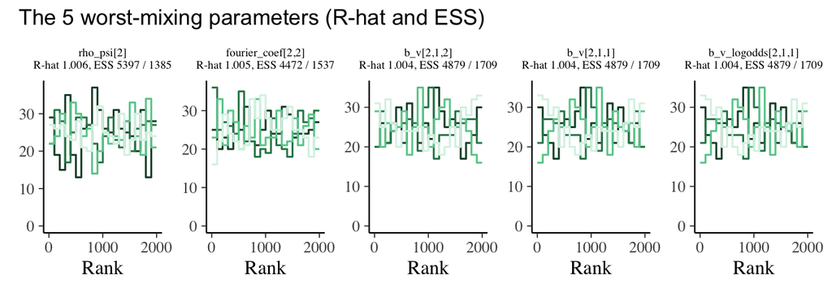

Figure 3: Rank plots of the five worst-mixing parameters, coloured green (good), orange (acceptable) or red (bad) by their R-hat and ESS.

```r
plot_post_traces(fit)
```

`log_lik` is one value per trial, so loo leaves out a whole trial at a time. A Pareto k above 0.7 marks a trial the fit leans on heavily, whose loo estimate is unreliable. A few are common with this few trials; many would mean loo comparisons need checking with K-fold cross-validation. `check_high_pareto_k()` lists those trials, worst first, with the person each belongs to (`z`).

```r
loo_result <- fit$loo()
loo_result
```

```
Computed from 2000 by 50 log-likelihood matrix.

         Estimate    SE
elpd_loo  -3702.5  62.9
p_loo        19.5   1.3
looic      7405.0 125.8
------
MCSE of elpd_loo is 0.1.
MCSE and ESS estimates assume MCMC draws (r_eff in [1.0, 2.1]).

All Pareto k estimates are good (k < 0.7).
See help('pareto-k-diagnostic') for details.
```

```r
# the trials with a high Pareto k, worst first
check_high_pareto_k(loo_result, sl)
```

```
# A tibble: 0 × 3
# ℹ 3 variables: trial_idx <int>, z <int>, k <dbl>
```

## 5 Posterior

Where a posterior sits well inside its prior band, the data rather than the prior set the estimate. A posterior pressed against the edge of its band means the prior is doing some of the work.

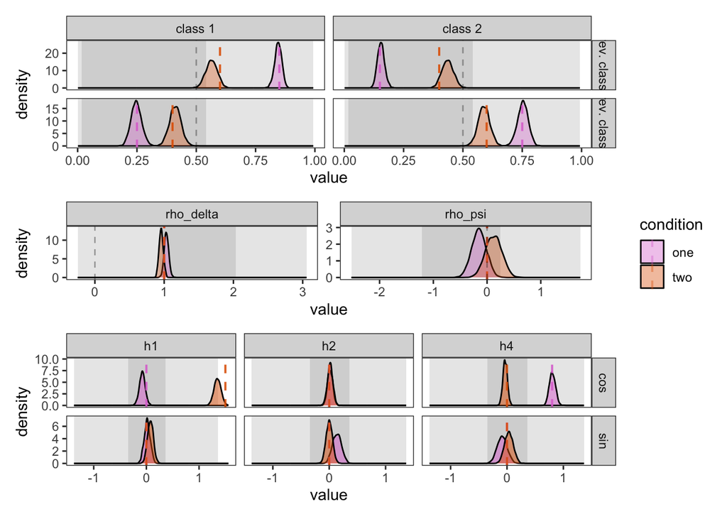

Figure 4: Posterior densities by condition. Grey bands: prior HPDIs; dashed lines: simulation values.

```r
post <- extract_post(fit, found, stim)
plot_post(post, groundtruth = simparams)
```

- Deterministic accuracy: how often the item the model judges most likely is the one selected.
- Probability of the chosen item: the probability the model gave the item that was selected, averaged over selections; it credits the model for being nearly right, not only for top picks.
- Chance (1 / items left) rises through a trial as fewer items remain.
- The nearest-neighbour baseline always picks the closest remaining item, so the gap above it is what the model adds to proximity alone.

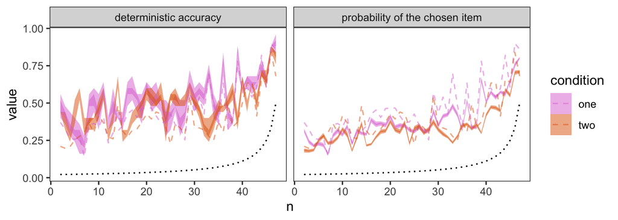

Figure 5: Accuracy of the model’s predictions at each selection, with chance and nearest-neighbour baselines.

```r
plot_post_accuracy(post$acc, stim, found)
```

## 6 Posterior predictive check

None of the trial statistics below is a model parameter, so reproducing them tests whether the fitted model captures aspects of the behaviour it was not fitted to directly. The model doesn’t predict when a trial stops, so each simulated trial keeps as many selections as the data have.

```r
sim_post <- sim_fomo(sl, fit, iter = n_post_draws)

# the model doesn't predict when a trial stops: keep as many simulated
# selections per trial as the data have
extract_pred(sim_post, stim) |>
  semi_join(found, by = c("trial", "n")) -> found_post
```

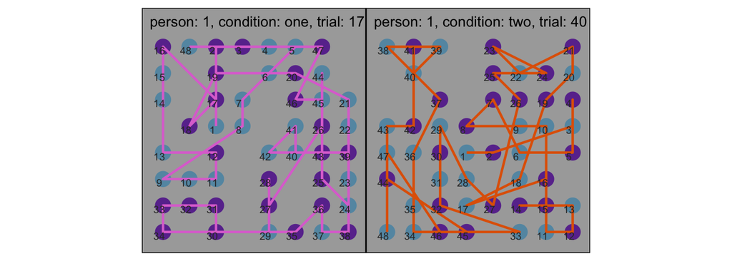

Figure 6: Trials simulated from the fitted model.

```r
plot_trial(found_post, stim)
```

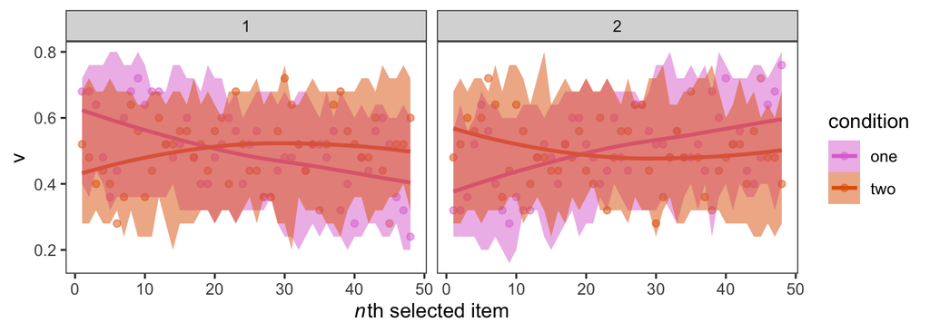

Figure 7: Proportion of each class selected at each point in a trial: fitted data vs data simulated from the posterior.

```r
plot_features(found, feature = "v", sim = found_post)
```

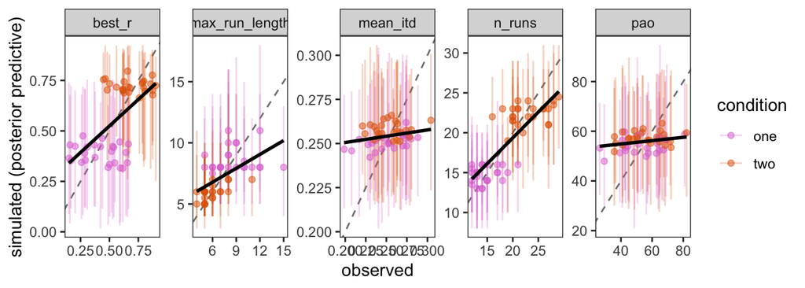

Figure 8: Trial statistics for the fitted data (x) and data simulated from the posterior (y). Points near the diagonal mean the model reproduces them.

```r
# compare per-trial foraging statistics between the training data and data
# simulated from the fitted posterior
sim_stats <- compute_trial_stats(found_post)
plot_trial_stats(trial_stats, sim_stats)
```